# Risk Factor Analysis

## Outcome Variable

**Outcome Variable:** haz

## Predictor Variables

**Intervention Variable:** fage

**Adjustment Set:**

unadjusted

## Stratifying Variables

The analysis was stratified on these variable(s):

- agecat
- studyid
- country

## Data Summary

| agecat | studyid | country | fage | n_cell | n |
| --- | --- | --- | --- | --- | --- |
| Birth | ki0047075b-MAL-ED | BANGLADESH | >=38 | 67 | 145 |
| Birth | ki0047075b-MAL-ED | BANGLADESH | <32 | 27 | 145 |
| Birth | ki0047075b-MAL-ED | BANGLADESH | [32-38) | 51 | 145 |
| Birth | ki0047075b-MAL-ED | BRAZIL | >=38 | 27 | 68 |
| Birth | ki0047075b-MAL-ED | BRAZIL | <32 | 16 | 68 |
| Birth | ki0047075b-MAL-ED | BRAZIL | [32-38) | 25 | 68 |
| Birth | ki0047075b-MAL-ED | INDIA | >=38 | 27 | 131 |
| Birth | ki0047075b-MAL-ED | INDIA | <32 | 44 | 131 |
| Birth | ki0047075b-MAL-ED | INDIA | [32-38) | 60 | 131 |
| Birth | ki0047075b-MAL-ED | NEPAL | >=38 | 13 | 61 |
| Birth | ki0047075b-MAL-ED | NEPAL | <32 | 9 | 61 |
| Birth | ki0047075b-MAL-ED | NEPAL | [32-38) | 39 | 61 |
| Birth | ki0047075b-MAL-ED | PERU | >=38 | 27 | 80 |
| Birth | ki0047075b-MAL-ED | PERU | <32 | 27 | 80 |
| Birth | ki0047075b-MAL-ED | PERU | [32-38) | 26 | 80 |
| Birth | ki0047075b-MAL-ED | SOUTH AFRICA | >=38 | 53 | 76 |
| Birth | ki0047075b-MAL-ED | SOUTH AFRICA | <32 | 8 | 76 |
| Birth | ki0047075b-MAL-ED | SOUTH AFRICA | [32-38) | 15 | 76 |
| Birth | ki0047075b-MAL-ED | TANZANIA, UNITED REPUBLIC OF | >=38 | 21 | 46 |
| Birth | ki0047075b-MAL-ED | TANZANIA, UNITED REPUBLIC OF | <32 | 6 | 46 |
| Birth | ki0047075b-MAL-ED | TANZANIA, UNITED REPUBLIC OF | [32-38) | 19 | 46 |
| Birth | ki1000304b-SAS-CompFeed | INDIA | >=38 | 4 | 187 |
| Birth | ki1000304b-SAS-CompFeed | INDIA | <32 | 152 | 187 |
| Birth | ki1000304b-SAS-CompFeed | INDIA | [32-38) | 31 | 187 |
| Birth | ki1119695-PROBIT | BELARUS | >=38 | 606 | 13390 |
| Birth | ki1119695-PROBIT | BELARUS | <32 | 10724 | 13390 |
| Birth | ki1119695-PROBIT | BELARUS | [32-38) | 2060 | 13390 |
| Birth | ki1135781-COHORTS | GUATEMALA | >=38 | 245 | 823 |
| Birth | ki1135781-COHORTS | GUATEMALA | <32 | 380 | 823 |
| Birth | ki1135781-COHORTS | GUATEMALA | [32-38) | 198 | 823 |

[output cut: 75 more lines]

The following strata were considered:

- agecat: 24 months, studyid: ki0047075b-MAL-ED, country: BANGLADESH
- agecat: 24 months, studyid: ki0047075b-MAL-ED, country: BRAZIL
- agecat: 24 months, studyid: ki0047075b-MAL-ED, country: INDIA
- agecat: 24 months, studyid: ki0047075b-MAL-ED, country: NEPAL
- agecat: 24 months, studyid: ki0047075b-MAL-ED, country: PERU
- agecat: 24 months, studyid: ki0047075b-MAL-ED, country: SOUTH AFRICA
- agecat: 24 months, studyid: ki0047075b-MAL-ED, country: TANZANIA, UNITED REPUBLIC OF
- agecat: 24 months, studyid: ki1119695-PROBIT, country: BELARUS
- agecat: 24 months, studyid: ki1135781-COHORTS, country: GUATEMALA
- agecat: 24 months, studyid: ki1135781-COHORTS, country: PHILIPPINES
- agecat: 24 months, studyid: ki1148112-LCNI-5, country: MALAWI
- agecat: 6 months, studyid: ki0047075b-MAL-ED, country: BANGLADESH
- agecat: 6 months, studyid: ki0047075b-MAL-ED, country: BRAZIL
- agecat: 6 months, studyid: ki0047075b-MAL-ED, country: INDIA
- agecat: 6 months, studyid: ki0047075b-MAL-ED, country: NEPAL
- agecat: 6 months, studyid: ki0047075b-MAL-ED, country: PERU
- agecat: 6 months, studyid: ki0047075b-MAL-ED, country: SOUTH AFRICA
- agecat: 6 months, studyid: ki0047075b-MAL-ED, country: TANZANIA, UNITED REPUBLIC OF
- agecat: 6 months, studyid: ki1000304b-SAS-CompFeed, country: INDIA
- agecat: 6 months, studyid: ki1000304b-SAS-FoodSuppl, country: INDIA
- agecat: 6 months, studyid: ki1119695-PROBIT, country: BELARUS
- agecat: 6 months, studyid: ki1135781-COHORTS, country: GUATEMALA
- agecat: 6 months, studyid: ki1135781-COHORTS, country: PHILIPPINES
- agecat: 6 months, studyid: ki1148112-LCNI-5, country: MALAWI
- agecat: Birth, studyid: ki0047075b-MAL-ED, country: BANGLADESH
- agecat: Birth, studyid: ki0047075b-MAL-ED, country: BRAZIL
- agecat: Birth, studyid: ki0047075b-MAL-ED, country: INDIA
- agecat: Birth, studyid: ki0047075b-MAL-ED, country: NEPAL
- agecat: Birth, studyid: ki0047075b-MAL-ED, country: PERU
- agecat: Birth, studyid: ki0047075b-MAL-ED, country: SOUTH AFRICA
- agecat: Birth, studyid: ki0047075b-MAL-ED, country: TANZANIA, UNITED REPUBLIC OF
- agecat: Birth, studyid: ki1000304b-SAS-CompFeed, country: INDIA
- agecat: Birth, studyid: ki1119695-PROBIT, country: BELARUS
- agecat: Birth, studyid: ki1135781-COHORTS, country: GUATEMALA
- agecat: Birth, studyid: ki1135781-COHORTS, country: PHILIPPINES

### Dropped Strata

Some strata were dropped due to rare outcomes:

- agecat: Birth, studyid: ki1000304b-SAS-CompFeed, country: INDIA

## Methods Detail

We’re interested in the causal parameters $E[Y_a]$ for all values of $a \in \mathcal{A}$. These parameters represent the mean outcome if, possibly contrary to fact, we intervened to set all units to have $A=a$. Under the randomization and positivity assumptions, these are identified by the statistical parameters $\psi_a=E_W[E_{Y|A,W}(Y|A=a,W)]$. In addition, we’re interested in the mean of $Y$, $E[Y]$ under no intervention (the observed mean). We will estimate these parameters by using SuperLearner to fit the relevant likelihood factors – $E_{Y|A,W}(Y|A=a,W)$ and $p(A=a|W)$, and then updating our likelihood fit using a joint TMLE.

For unadjusted analyses ($W=\{\}$), initial likelihoods were estimated using Lrnr_glm to estimate the simple $E(Y|A)$ and Lrnr_mean to estimate $p(A)$. For adjusted analyses, a small library containing Lrnr_glmnet, Lrnr_xgboost, and Lrnr_mean was used.

Having estimated these parameters, we will then use the delta method to estimate relative risks and attributable risks relative to a prespecified baseline level of $A$.

# Results Detail

## Results Plots

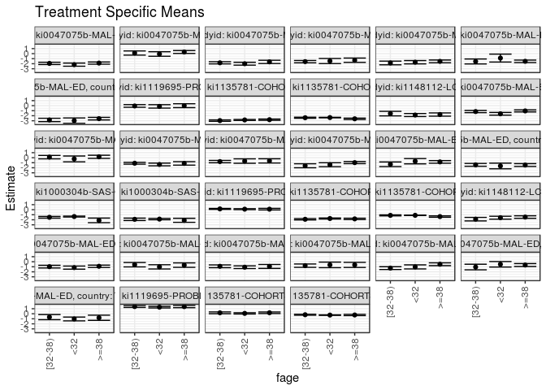

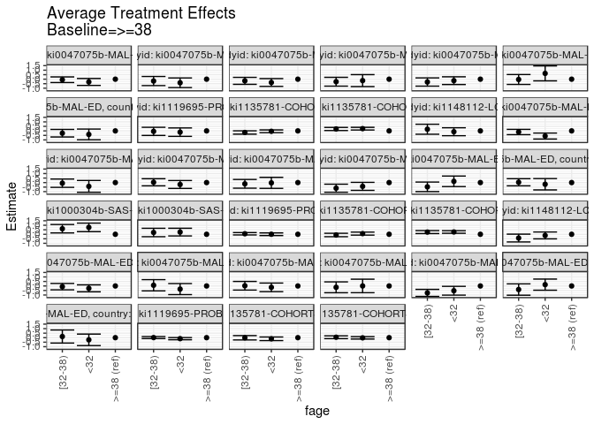

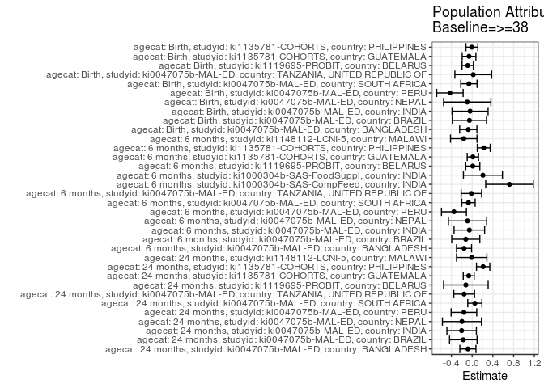

## Results Table

### Parameter: TSM

| agecat | studyid | country | intervention_level | baseline_level | estimate | ci_lower | ci_upper |
| --- | --- | --- | --- | --- | --- | --- | --- |
| Birth | ki0047075b-MAL-ED | BANGLADESH | >=38 | NA | -0.9028358 | -1.1330574 | -0.6726143 |
| Birth | ki0047075b-MAL-ED | BANGLADESH | <32 | NA | -1.1637037 | -1.4727896 | -0.8546178 |
| Birth | ki0047075b-MAL-ED | BANGLADESH | [32-38) | NA | -0.9780392 | -1.2454084 | -0.7106700 |
| Birth | ki0047075b-MAL-ED | BRAZIL | >=38 | NA | -0.6711111 | -1.1133744 | -0.2288478 |
| Birth | ki0047075b-MAL-ED | BRAZIL | <32 | NA | -1.0175000 | -1.4396816 | -0.5953184 |
| Birth | ki0047075b-MAL-ED | BRAZIL | [32-38) | NA | -0.5928000 | -1.0308980 | -0.1547020 |
| Birth | ki0047075b-MAL-ED | INDIA | >=38 | NA | -0.9318519 | -1.3231138 | -0.5405899 |
| Birth | ki0047075b-MAL-ED | INDIA | <32 | NA | -1.0840909 | -1.3536140 | -0.8145678 |
| Birth | ki0047075b-MAL-ED | INDIA | [32-38) | NA | -0.9080000 | -1.1841255 | -0.6318745 |
| Birth | ki0047075b-MAL-ED | NEPAL | >=38 | NA | -0.6300000 | -1.1327994 | -0.1272006 |
| Birth | ki0047075b-MAL-ED | NEPAL | <32 | NA | -0.6277778 | -1.1813379 | -0.0742177 |
| Birth | ki0047075b-MAL-ED | NEPAL | [32-38) | NA | -0.7782051 | -1.1107483 | -0.4456620 |
| Birth | ki0047075b-MAL-ED | PERU | >=38 | NA | -0.4970370 | -0.7736456 | -0.2204285 |
| Birth | ki0047075b-MAL-ED | PERU | <32 | NA | -1.0255556 | -1.4266503 | -0.6244608 |
| Birth | ki0047075b-MAL-ED | PERU | [32-38) | NA | -1.2669231 | -1.5437232 | -0.9901230 |
| Birth | ki0047075b-MAL-ED | SOUTH AFRICA | >=38 | NA | -0.6554717 | -0.9459850 | -0.3649584 |
| Birth | ki0047075b-MAL-ED | SOUTH AFRICA | <32 | NA | -0.5087500 | -1.0529159 | 0.0354159 |
| Birth | ki0047075b-MAL-ED | SOUTH AFRICA | [32-38) | NA | -1.0513333 | -1.6086365 | -0.4940302 |
| Birth | ki0047075b-MAL-ED | TANZANIA, UNITED REPUBLIC OF | >=38 | NA | -0.7961905 | -1.3086490 | -0.2837320 |
| Birth | ki0047075b-MAL-ED | TANZANIA, UNITED REPUBLIC OF | <32 | NA | -1.0350000 | -1.4136675 | -0.6563325 |
| Birth | ki0047075b-MAL-ED | TANZANIA, UNITED REPUBLIC OF | [32-38) | NA | -0.6684211 | -1.1811565 | -0.1556856 |
| Birth | ki1119695-PROBIT | BELARUS | >=38 | NA | 1.4199835 | 1.2040261 | 1.6359409 |
| Birth | ki1119695-PROBIT | BELARUS | <32 | NA | 1.3112402 | 1.1542436 | 1.4682369 |
| Birth | ki1119695-PROBIT | BELARUS | [32-38) | NA | 1.4286553 | 1.2446278 | 1.6126829 |
| Birth | ki1135781-COHORTS | GUATEMALA | >=38 | NA | 0.1978367 | 0.0395926 | 0.3560809 |
| Birth | ki1135781-COHORTS | GUATEMALA | <32 | NA | 0.0741053 | -0.0485386 | 0.1967491 |
| Birth | ki1135781-COHORTS | GUATEMALA | [32-38) | NA | 0.1853535 | 0.0041042 | 0.3666029 |
| Birth | ki1135781-COHORTS | PHILIPPINES | >=38 | NA | -0.2416159 | -0.3642496 | -0.1189821 |
| Birth | ki1135781-COHORTS | PHILIPPINES | <32 | NA | -0.2615825 | -0.3083191 | -0.2148459 |
| Birth | ki1135781-COHORTS | PHILIPPINES | [32-38) | NA | -0.1932775 | -0.2878017 | -0.0987532 |

[output cut: 72 more lines]

### Parameter: E(Y)

| agecat | studyid | country | intervention_level | baseline_level | estimate | ci_lower | ci_upper |
| --- | --- | --- | --- | --- | --- | --- | --- |
| Birth | ki0047075b-MAL-ED | BANGLADESH | NA | NA | -0.9778621 | -1.1318533 | -0.8238709 |
| Birth | ki0047075b-MAL-ED | BRAZIL | NA | NA | -0.7238235 | -0.9850427 | -0.4626043 |
| Birth | ki0047075b-MAL-ED | INDIA | NA | NA | -0.9720611 | -1.1477959 | -0.7963262 |
| Birth | ki0047075b-MAL-ED | NEPAL | NA | NA | -0.7244262 | -0.9767822 | -0.4720703 |
| Birth | ki0047075b-MAL-ED | PERU | NA | NA | -0.9256250 | -1.1260052 | -0.7252448 |
| Birth | ki0047075b-MAL-ED | SOUTH AFRICA | NA | NA | -0.7181579 | -0.9588306 | -0.4774852 |
| Birth | ki0047075b-MAL-ED | TANZANIA, UNITED REPUBLIC OF | NA | NA | -0.7745652 | -1.0958030 | -0.4533274 |
| Birth | ki1119695-PROBIT | BELARUS | NA | NA | 1.3342255 | 1.1742855 | 1.4941656 |
| Birth | ki1135781-COHORTS | GUATEMALA | NA | NA | 0.1377035 | 0.0520086 | 0.2233984 |
| Birth | ki1135781-COHORTS | PHILIPPINES | NA | NA | -0.2468988 | -0.2865742 | -0.2072233 |
| 6 months | ki0047075b-MAL-ED | BANGLADESH | NA | NA | -1.1979000 | -1.3314769 | -1.0643231 |
| 6 months | ki0047075b-MAL-ED | BRAZIL | NA | NA | 0.0554008 | -0.1690575 | 0.2798592 |
| 6 months | ki0047075b-MAL-ED | INDIA | NA | NA | -1.1894617 | -1.3346428 | -1.0442806 |
| 6 months | ki0047075b-MAL-ED | NEPAL | NA | NA | -0.7256962 | -0.9111717 | -0.5402207 |
| 6 months | ki0047075b-MAL-ED | PERU | NA | NA | -1.3300201 | -1.5375346 | -1.1225056 |
| 6 months | ki0047075b-MAL-ED | SOUTH AFRICA | NA | NA | -0.9083333 | -1.1234247 | -0.6932420 |
| 6 months | ki0047075b-MAL-ED | TANZANIA, UNITED REPUBLIC OF | NA | NA | -1.4744833 | -1.6639782 | -1.2849884 |
| 6 months | ki1000304b-SAS-CompFeed | INDIA | NA | NA | -1.4006377 | -1.4802862 | -1.3209891 |
| 6 months | ki1000304b-SAS-FoodSuppl | INDIA | NA | NA | -1.8986842 | -2.0118892 | -1.7854792 |
| 6 months | ki1119695-PROBIT | BELARUS | NA | NA | 0.1166130 | 0.0230160 | 0.2102100 |
| 6 months | ki1135781-COHORTS | GUATEMALA | NA | NA | -1.8068353 | -1.8758487 | -1.7378219 |
| 6 months | ki1135781-COHORTS | PHILIPPINES | NA | NA | -1.1421265 | -1.1845116 | -1.0997415 |
| 6 months | ki1148112-LCNI-5 | MALAWI | NA | NA | -1.6211321 | -1.8052501 | -1.4370141 |
| 24 months | ki0047075b-MAL-ED | BANGLADESH | NA | NA | -1.9567550 | -2.0984173 | -1.8150926 |
| 24 months | ki0047075b-MAL-ED | BRAZIL | NA | NA | 0.1588608 | -0.0651474 | 0.3828689 |
| 24 months | ki0047075b-MAL-ED | INDIA | NA | NA | -1.8373292 | -1.9909581 | -1.6837003 |
| 24 months | ki0047075b-MAL-ED | NEPAL | NA | NA | -1.5030380 | -1.6956243 | -1.3104516 |
| 24 months | ki0047075b-MAL-ED | PERU | NA | NA | -1.6960127 | -1.8853995 | -1.5066258 |
| 24 months | ki0047075b-MAL-ED | SOUTH AFRICA | NA | NA | -1.4697191 | -1.6840618 | -1.2553764 |
| 24 months | ki0047075b-MAL-ED | TANZANIA, UNITED REPUBLIC OF | NA | NA | -2.7318500 | -2.9253580 | -2.5383420 |
| 24 months | ki1119695-PROBIT | BELARUS | NA | NA | -0.1254844 | -0.4225624 | 0.1715937 |
| 24 months | ki1135781-COHORTS | GUATEMALA | NA | NA | -2.8513770 | -2.9170436 | -2.7857104 |
| 24 months | ki1135781-COHORTS | PHILIPPINES | NA | NA | -2.3958878 | -2.4412250 | -2.3505506 |
| 24 months | ki1148112-LCNI-5 | MALAWI | NA | NA | -1.7689189 | -1.9714091 | -1.5664287 |

### Parameter: ATE

| agecat | studyid | country | intervention_level | baseline_level | estimate | ci_lower | ci_upper |
| --- | --- | --- | --- | --- | --- | --- | --- |
| Birth | ki0047075b-MAL-ED | BANGLADESH | >=38 | >=38 | 0.0000000 | 0.0000000 | 0.0000000 |
| Birth | ki0047075b-MAL-ED | BANGLADESH | <32 | >=38 | -0.2608679 | -0.6462716 | 0.1245359 |
| Birth | ki0047075b-MAL-ED | BANGLADESH | [32-38) | >=38 | -0.0752034 | -0.4280323 | 0.2776255 |
| Birth | ki0047075b-MAL-ED | BRAZIL | >=38 | >=38 | 0.0000000 | 0.0000000 | 0.0000000 |
| Birth | ki0047075b-MAL-ED | BRAZIL | <32 | >=38 | -0.3463889 | -0.9578087 | 0.2650309 |
| Birth | ki0047075b-MAL-ED | BRAZIL | [32-38) | >=38 | 0.0783111 | -0.5442053 | 0.7008275 |
| Birth | ki0047075b-MAL-ED | INDIA | >=38 | >=38 | 0.0000000 | 0.0000000 | 0.0000000 |
| Birth | ki0047075b-MAL-ED | INDIA | <32 | >=38 | -0.1522391 | -0.6273482 | 0.3228701 |
| Birth | ki0047075b-MAL-ED | INDIA | [32-38) | >=38 | 0.0238519 | -0.4550335 | 0.5027372 |
| Birth | ki0047075b-MAL-ED | NEPAL | >=38 | >=38 | 0.0000000 | 0.0000000 | 0.0000000 |
| Birth | ki0047075b-MAL-ED | NEPAL | <32 | >=38 | 0.0022222 | -0.7455986 | 0.7500431 |
| Birth | ki0047075b-MAL-ED | NEPAL | [32-38) | >=38 | -0.1482051 | -0.7510253 | 0.4546151 |
| Birth | ki0047075b-MAL-ED | PERU | >=38 | >=38 | 0.0000000 | 0.0000000 | 0.0000000 |
| Birth | ki0047075b-MAL-ED | PERU | <32 | >=38 | -0.5285185 | -1.0157446 | -0.0412924 |
| Birth | ki0047075b-MAL-ED | PERU | [32-38) | >=38 | -0.7698860 | -1.1612051 | -0.3785670 |
| Birth | ki0047075b-MAL-ED | SOUTH AFRICA | >=38 | >=38 | 0.0000000 | 0.0000000 | 0.0000000 |
| Birth | ki0047075b-MAL-ED | SOUTH AFRICA | <32 | >=38 | 0.1467217 | -0.4701368 | 0.7635802 |
| Birth | ki0047075b-MAL-ED | SOUTH AFRICA | [32-38) | >=38 | -0.3958616 | -1.0243398 | 0.2326165 |
| Birth | ki0047075b-MAL-ED | TANZANIA, UNITED REPUBLIC OF | >=38 | >=38 | 0.0000000 | 0.0000000 | 0.0000000 |
| Birth | ki0047075b-MAL-ED | TANZANIA, UNITED REPUBLIC OF | <32 | >=38 | -0.2388095 | -0.8759930 | 0.3983740 |
| Birth | ki0047075b-MAL-ED | TANZANIA, UNITED REPUBLIC OF | [32-38) | >=38 | 0.1277694 | -0.5971522 | 0.8526911 |
| Birth | ki1119695-PROBIT | BELARUS | >=38 | >=38 | 0.0000000 | 0.0000000 | 0.0000000 |
| Birth | ki1119695-PROBIT | BELARUS | <32 | >=38 | -0.1087433 | -0.2286625 | 0.0111759 |
| Birth | ki1119695-PROBIT | BELARUS | [32-38) | >=38 | 0.0086718 | -0.1026943 | 0.1200380 |
| Birth | ki1135781-COHORTS | GUATEMALA | >=38 | >=38 | 0.0000000 | 0.0000000 | 0.0000000 |
| Birth | ki1135781-COHORTS | GUATEMALA | <32 | >=38 | -0.1237315 | -0.3239382 | 0.0764752 |
| Birth | ki1135781-COHORTS | GUATEMALA | [32-38) | >=38 | -0.0124832 | -0.2530919 | 0.2281255 |
| Birth | ki1135781-COHORTS | PHILIPPINES | >=38 | >=38 | 0.0000000 | 0.0000000 | 0.0000000 |
| Birth | ki1135781-COHORTS | PHILIPPINES | <32 | >=38 | -0.0199666 | -0.1512044 | 0.1112711 |
| Birth | ki1135781-COHORTS | PHILIPPINES | [32-38) | >=38 | 0.0483384 | -0.1064966 | 0.2031733 |

[output cut: 72 more lines]

### Parameter: PAR

| agecat | studyid | country | intervention_level | baseline_level | estimate | ci_lower | ci_upper |
| --- | --- | --- | --- | --- | --- | --- | --- |
| Birth | ki0047075b-MAL-ED | BANGLADESH | >=38 | NA | -0.0750262 | -0.2415619 | 0.0915094 |
| Birth | ki0047075b-MAL-ED | BRAZIL | >=38 | NA | -0.0527124 | -0.3821140 | 0.2766892 |
| Birth | ki0047075b-MAL-ED | INDIA | >=38 | NA | -0.0402092 | -0.3878650 | 0.3074466 |
| Birth | ki0047075b-MAL-ED | NEPAL | >=38 | NA | -0.0944262 | -0.5513035 | 0.3624511 |
| Birth | ki0047075b-MAL-ED | PERU | >=38 | NA | -0.4285880 | -0.6835756 | -0.1736003 |
| Birth | ki0047075b-MAL-ED | SOUTH AFRICA | >=38 | NA | -0.0626862 | -0.2195568 | 0.0941844 |
| Birth | ki0047075b-MAL-ED | TANZANIA, UNITED REPUBLIC OF | >=38 | NA | 0.0216253 | -0.3333814 | 0.3766319 |
| Birth | ki1119695-PROBIT | BELARUS | >=38 | NA | -0.0857580 | -0.1955537 | 0.0240378 |
| Birth | ki1135781-COHORTS | GUATEMALA | >=38 | NA | -0.0601332 | -0.1923290 | 0.0720626 |
| Birth | ki1135781-COHORTS | PHILIPPINES | >=38 | NA | -0.0052829 | -0.1204440 | 0.1098782 |
| 6 months | ki0047075b-MAL-ED | BANGLADESH | >=38 | NA | -0.1564749 | -0.3014291 | -0.0115206 |
| 6 months | ki0047075b-MAL-ED | BRAZIL | >=38 | NA | -0.1226547 | -0.3935922 | 0.1482828 |
| 6 months | ki0047075b-MAL-ED | INDIA | >=38 | NA | -0.0542302 | -0.3491062 | 0.2406458 |
| 6 months | ki0047075b-MAL-ED | NEPAL | >=38 | NA | -0.0892256 | -0.4580153 | 0.2795641 |
| 6 months | ki0047075b-MAL-ED | PERU | >=38 | NA | -0.3516250 | -0.5919408 | -0.1113092 |
| 6 months | ki0047075b-MAL-ED | SOUTH AFRICA | >=38 | NA | -0.0709375 | -0.1999633 | 0.0580883 |
| 6 months | ki0047075b-MAL-ED | TANZANIA, UNITED REPUBLIC OF | >=38 | NA | -0.0149694 | -0.2125504 | 0.1826116 |
| 6 months | ki1000304b-SAS-CompFeed | INDIA | >=38 | NA | 0.7204987 | 0.2615501 | 1.1794473 |
| 6 months | ki1000304b-SAS-FoodSuppl | INDIA | >=38 | NA | 0.2079825 | -0.1684007 | 0.5843656 |
| 6 months | ki1119695-PROBIT | BELARUS | >=38 | NA | 0.0125902 | -0.1232637 | 0.1484440 |
| 6 months | ki1135781-COHORTS | GUATEMALA | >=38 | NA | 0.0136011 | -0.0955179 | 0.1227200 |
| 6 months | ki1135781-COHORTS | PHILIPPINES | >=38 | NA | 0.2235735 | 0.0985930 | 0.3485540 |
| 6 months | ki1148112-LCNI-5 | MALAWI | >=38 | NA | -0.1622859 | -0.4176154 | 0.0930435 |
| 24 months | ki0047075b-MAL-ED | BANGLADESH | >=38 | NA | -0.0822622 | -0.2376826 | 0.0731581 |
| 24 months | ki0047075b-MAL-ED | BRAZIL | >=38 | NA | -0.1706392 | -0.4359516 | 0.0946731 |
| 24 months | ki0047075b-MAL-ED | INDIA | >=38 | NA | -0.2028847 | -0.4872603 | 0.0814908 |
| 24 months | ki0047075b-MAL-ED | NEPAL | >=38 | NA | -0.1971556 | -0.5737747 | 0.1794635 |
| 24 months | ki0047075b-MAL-ED | PERU | >=38 | NA | -0.1587050 | -0.4060582 | 0.0886483 |
| 24 months | ki0047075b-MAL-ED | SOUTH AFRICA | >=38 | NA | 0.0515886 | -0.0850395 | 0.1882167 |
| 24 months | ki0047075b-MAL-ED | TANZANIA, UNITED REPUBLIC OF | >=38 | NA | -0.1543500 | -0.3544839 | 0.0457839 |
| 24 months | ki1119695-PROBIT | BELARUS | >=38 | NA | -0.1212147 | -0.5511206 | 0.3086912 |
| 24 months | ki1135781-COHORTS | GUATEMALA | >=38 | NA | -0.0663945 | -0.1714668 | 0.0386778 |
| 24 months | ki1135781-COHORTS | PHILIPPINES | >=38 | NA | 0.2120011 | 0.0834076 | 0.3405945 |
| 24 months | ki1148112-LCNI-5 | MALAWI | >=38 | NA | -0.0084427 | -0.3012751 | 0.2843897 |